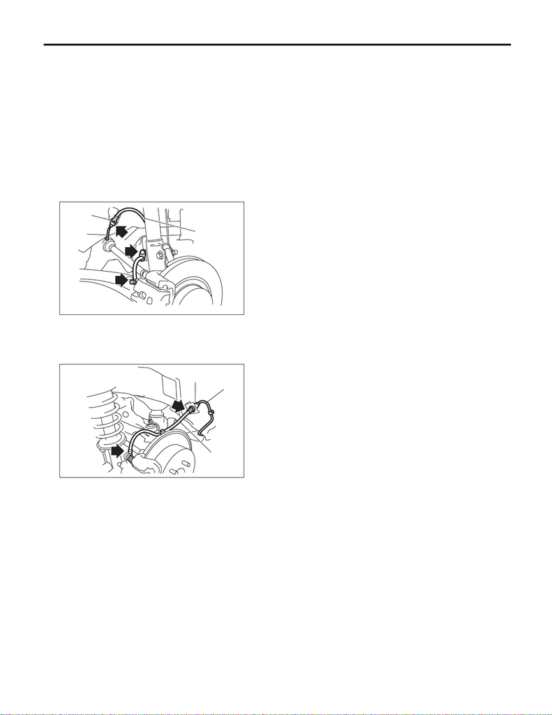

PM-20

Brake Line

PERIODIC MAINTENANCE SERVICES

17.Brake Line

A: INSPECTION

1. BRAKE LINE

1) Check for scratches, swelling, corrosion, traces of fluid leakage on the brake hoses or pipe joints.

2) Make sure that brake pipes/hoses do not interfere with adjacent parts and there is no loose connector/

clamp during driving.

3) Check any trace of fluid leakage, scratches, etc. on master cylinder, wheel cylinder and hydraulic unit.

NOTE:

• When the brake fluid level in the reservoir tank is lower than specified limit, the brake warning light on the

combination meter will illuminate.

• Visually check the brake hose for damage. (Use a mirror where it is difficult to see)

2. SERVICE BRAKE

Refer to “BR” section for foot brake inspection. <Ref. to BR-75, INSPECTION, Brake Pedal.>

(1)

(2)

(3)

PM-00465

(1) Front brake hose

(2) Front brake pipe

(3) Clamp

PM-00574

(3)

(1)

(2)

(1) Brake pipe

(2) Rear brake hose

(3) Clamp

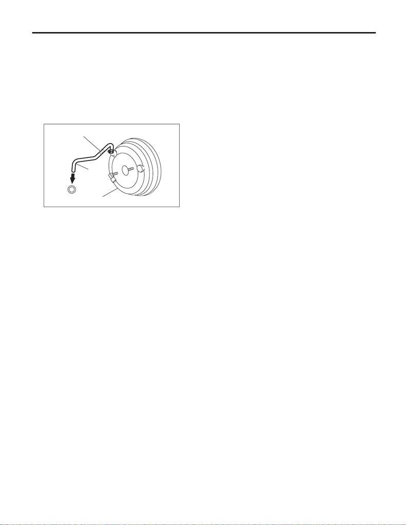

PM-21

Brake Line

PERIODIC MAINTENANCE SERVICES

3. BRAKE SERVO SYSTEM

1) With the engine off, depress the brake pedal several times applying the same pedal force. Check that the

travel distance should not change.

2) With the brake pedal depressed, start the engine. Check that the pedal moves slightly toward the floor.

3) With the brake pedal depressed, stop the engine and keep the pedal depressed for 30 seconds. Check

that the pedal height does not change.

4) A check valve is built into the brake booster nipple. Disconnect the vacuum hose to inspect function of

check valve.

Check that check valve ventilates from booster side to engine side. Also, check that there is no ventilation

from engine side to booster side.

5) Check the vacuum hose for cracks or other damage.

CAUTION:

When installing the vacuum hose on the engine and brake booster, do not use soapy water or lubri-

cating oil on their connections.

6) Check that the vacuum hose is securely tightened.

(A)

(B)

(C)

(D)

PM-00733

(A) Brake booster

(B) Check valve

(C) Engine side

(D) Brake booster side